# Flow Chart with R Package *diagram*

Rho

Most flow charts are made up of three main types of symbol:

- Elongated circles, which signify the start or end of a process;
- Rectangles, which show instructions or actions;
- Diamonds, which show decisions that must be made

`openplotmat()` create a plotting region; `coordinates()` specifies the coordinates of elements; `textplain()`, `textround()`, `textdiamond()`, `textrect()` etc add elements; `straightarrow()`, `curvedarrow()`, `bentarrow()` and `segmentarrow()` etc links 2 or more elements

## Coordinates

```
coordinates(pos = NULL, mx = 0, my = 0, N = length(pos),
            hor = TRUE, relsize = 1, ...)
```

- mx: horizontal shift (x)
- my: vertical shift (y)
- pos: element position
  - *NULL* the elements will be arranged on a circle; in this case, the number of elements to be positioned must be specified with N.
  - *vector* specifying the number of elements from top row to bottom row (if hor = TRUE) or in each column (if hor = FALSE)
  - *matrix* specifying the x(1st column) and y(2nd column) position of each element

```r
require('diagram')
M_vec <- coordinates(pos = c(1, 2, 3, 1))

POS <- c(1, 2, 3, 1)
y <- rep(1/(length(POS) * 2) * seq(to = 1, along.with = POS, by = -2), POS)
x1 <- rep(1/(POS * 2), POS)
SEQ <- unlist(sapply(POS, FUN = function(x) seq(from = 1, by =2, length = x)))
x <- x1 * SEQ
M_vec1 <- unname(cbind(x, y))
identical(M_vec1, M_vec)
```

```
## [1] TRUE
```

```r
M_vec
```

```
##           [,1]  [,2]
## [1,] 0.5000000 0.875
## [2,] 0.2500000 0.625
## [3,] 0.7500000 0.625
## [4,] 0.1666667 0.375
## [5,] 0.5000000 0.375
## [6,] 0.8333333 0.375
## [7,] 0.5000000 0.125
```

We can also specifies element positions with x (1st col) and y(2nd col)

```r
M_mat <- matrix(c(0.6, 0.8,
                  0.3, 0.6,
                  0.7, 0.6,
                  0.2, 0.3,
                  0.5, 0.3,
                  0.7, 0.3),
                nrow = 6, ncol = 2, byrow = TRUE)
```

## Arrows

common args: from, to, lwd, lty, lcol, arr.col, arr.pos, etc.

- straightarrow()
- curvedarrow(curve = 1, dr = 0.01)
- bentarrow(arr.side = 2, path = ‘H’) first horizontal then vertical, with ‘V’ first vertical then horizontal
- treearrow(path = ‘H’)
- splitarrow(dd = 0.5)
- segmentarrow(path = ‘LVR’, dd = 0.5)
- selfarrow(path = ‘L’) R, L, U, D for right, left, up and down respectively

as to segmentarrow, “LVR”(first left then vertical then right); “RVL”; “UHD”(first up then horizontal then down); “DHU”; dd: length of segment arm, directed away from endpoints.

## Text

- textempty
- textplain
- textrect
- textellipse
- textround
- textdiamond
- texthexa
- textmulti

```
textrect(mid, radx, rady=radx*length(lab), lwd=1,
  shadow.size=0.01, adj=c(0.5,0.5), lab="", box.col="white",
  lcol="black", shadow.col="grey", angle=0, font=1...)
```

- mid: midpoint (x,y) of the box
- radx: horizontal radius of the box.
- adj: text adjustment.
- angle: rotation angle, degrees.
- font: 1(plain); 2(bold); 3(italic); 4(bold-italic)

## Example

Note: Please draw arrows, then text.

### Ex1

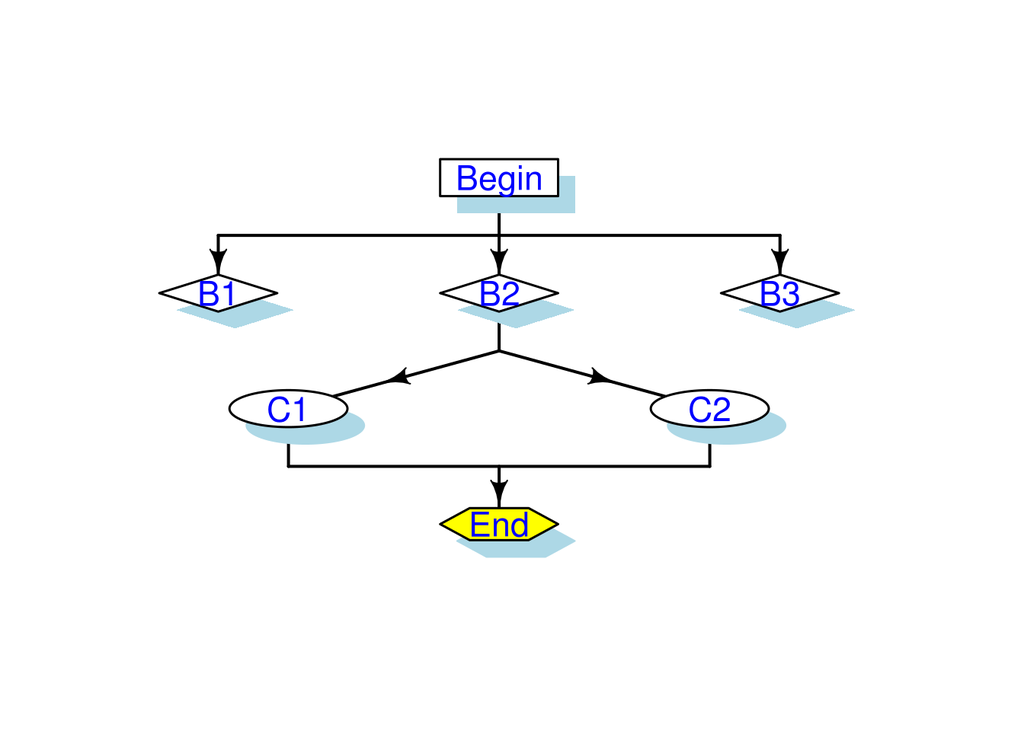

```r
openplotmat()
M <- coordinates(pos = c(1, 3, 2, 1), mx = -0.05)

treearrow(from = M[1, ], to = M[2:4,], arr.side = 2, arr.pos = 0.5)
splitarrow(from = M[3, ], to = M[5:6, ])
treearrow(from = M[5:6, ], to = M[7, ],
          arr.side = 2, arr.pos = 0.5)

textrect(mid = M[1, ], radx = 0.07, rady = 0.04,
        lwd = 1.5, cex = 1.4, shadow.size = 0.02,
        shadow.col = 'lightblue', col = 'blue', lab = 'Begin')
nm1 <- paste('B', 1:3, sep = '')
nm2 <- paste('C', 1:2, sep = '')
for(i in 2:4)textdiamond(mid=M[i,],radx=0.07,rady=0.04,lwd=1.5,cex=1.4,
   shadow.size=0.02,shadow.col='lightblue',col='blue',lab=nm1[i-1])
for(i in 5:6)textellipse(mid=M[i,],radx=0.07,rady=0.04,lwd=1.5,cex=1.4,
   shadow.size=0.02,shadow.col='lightblue',col='blue',lab=nm2[i-4])
textmulti(mid=M[7,],radx=0.07,rady=0.04,lwd=1.5,cex=1.4,shadow.size=0.02,
   shadow.col='lightblue',col='blue',lab='End',box.col='yellow')
```

### Ex2

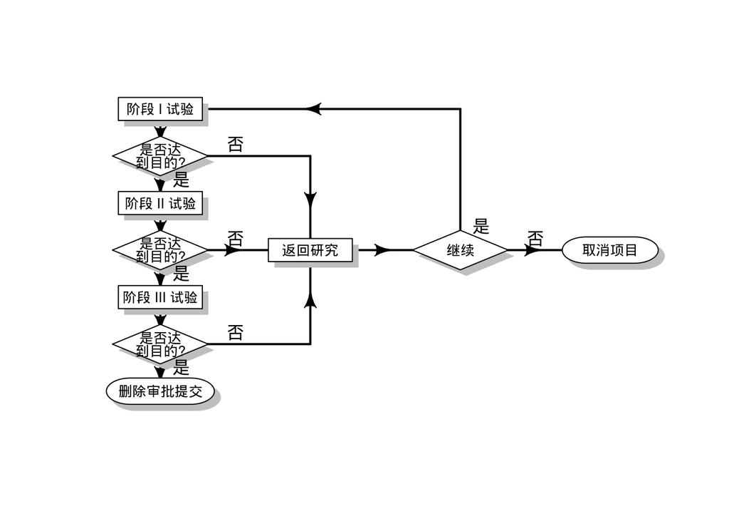

```r
m2 <- coordinates(pos = rep(4, 7))

openplotmat()

for(i in c(1, 9, 17)) straightarrow(from = m2[i, ], to = m2[i + 4, ], arr.pos = 0.6)
for(i in c(5, 13, 21)) straightarrow(from = m2[i, ], to = m2[i + 4, ], arr.pos = 0.7)
for(i in 13:15) straightarrow(from = m2[i, ], to = m2[i + 1, ])

bentarrow(from = m2[15, ], to = m2[1, ], path = 'V')
bentarrow(from = m2[5, ], to = m2[14, ], path = 'H')
bentarrow(from = m2[21, ], to = m2[14, ], path = 'H')

textrect(m2[1, ], radx = 0.07, rady = 0.035, lab = c("阶段 I 试验"), cex = 0.8)
textrect(m2[9, ], radx = 0.07, rady = 0.035, lab = c("阶段 II 试验"), cex = 0.8)
textrect(m2[17, ], radx = 0.07, rady = 0.035, lab = c("阶段 III 试验"), cex = 0.8)
textrect(m2[14, ], radx = 0.07, rady = 0.035, lab = c("返回研究"), cex = 0.8)

for(i in c(5, 13, 21))textdiamond(m2[i, ], radx = 0.08, rady = 0.06, lab = c("是否达","到目的?"), cex = 0.8)
textdiamond(m2[15, ], radx = 0.08, rady = 0.06, lab = c("继续"), cex = 0.8)

textround(m2[25, ], radx = 0.05, rady = 0.04, lab = c("删除审批提交"), cex = 0.8)
textround(m2[16, ], radx = 0.04, rady = 0.04, lab = c("取消项目"), cex = 0.8)

for(i in c(5, 11, 13, 21)) text(m2[i, 1] + 0.035, (m2[i, 2] + m2[i + 4, 2])/2, "是")
for(i in c(5, 13, 15, 21)) text((m2[i, 1] + m2[i + 1, 1])/2, m2[i, 2] + 0.035, "否")
```